# Intro to rmarkdown

```r
library(readr)
```

## Headers

#### Header at a deeper level

Now I am writing some text to try to figure out what is going on here.

- This is a list
- The second thing on list
- this
  - list with pluses
  - second **thing** in list with pluses

*Italic text*

Numbered list

1. This is first
2. this is next
3. this is third

Oh this is very cool, you can say that there are 50 cars.

I also didn’t realize you can end a line  
with two or more spaces

I know how to make links

> What are block quotes I want to know

$equation$

$$equation$$
Three or more asterisks is a page break

superscript<sup>2</sup>

subscript<sub>2</sub>

strikethrough

You can use the funky visual method to do citations. (YASHIRO et al. 2019)

This is a table of things we do

| Species | Number | Drawing |
| --- | --- | --- |
| Anax strenuus | 48 | no |
| Anax walsinghami | 15 |  |

#### First code chunk

Command-option-i will insert a new code chunk for you

```r
x<-mean(c(1,3,2,4,7))
print(x)
```

```
## [1] 3.4
```

```r
carsy<-cars[4,]
head(carsy)
```

```
##   speed dist
## 4     7   22
```

```r
print("I can do this!")
```

```
## [1] "I can do this!"
```

## Introduction

- read in and reference data source

```r
bg_chem<-read_csv("BGchem2008data.csv")
head(bg_chem)
```

```
## # A tibble: 6 x 19
##   Date       Time                Station Latitude Longitude Target_Depth
##   <date>     <dttm>              <chr>      <dbl>     <dbl>        <dbl>
## 1 2008-03-21 1899-12-31 21:56:46 73N,14…     73.0     -140.           20
## 2 2008-03-21 1899-12-31 21:56:46 73N,14…     73.0     -140.           60
## 3 2008-03-21 1899-12-31 21:56:46 73N,14…     73.0     -140.           85
## 4 2008-03-21 1899-12-31 21:56:46 73N,14…     73.0     -140.          190
## 5 2008-03-21 1899-12-31 21:56:46 73N,14…     73.0     -140.          310
## 6 2008-03-22 1899-12-31 21:45:27 72N,14…     72.1     -140.           20
## # … with 13 more variables: CTD_Depth <dbl>, CTD_Salinity <dbl>,
## #   CTD_Temperature <dbl>, Bottle_Salinity <dbl>, d18O <dbl>, Ba <dbl>,
## #   Si <dbl>, NO3 <dbl>, NO2 <dbl>, NH4 <dbl>, P <dbl>, TA <dbl>, O2 <dbl>
```

## Analysis

- Calculate basic summary stats

```r
NO3_mean<-mean(bg_chem$NO3)
NO2_mean<-mean(bg_chem$NO2)
NH4_mean<-mean(bg_chem$NH4)
P_mean<-mean(bg_chem$P)
```

The mean of Nitrate is 6.86.  
The mean of Nitrite is 0.05.  
The mean of ammonia is 0.06.  
The mean of phosphorus is 1.12.

- calculate mean redfield ratio

```r
red<-(NO3_mean+NO2_mean+NH4_mean)/P_mean
```

The Redfield ratio is 6.22.

- plot redfield ratio

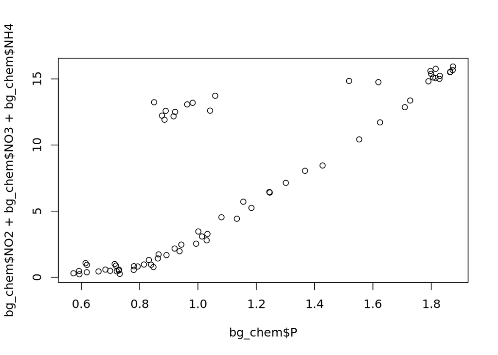

YASHIRO, TOSHIHISA, YOKO TAKEMATSU, NAOKI OGAWA, and KENJI MATSUURA. 2019. “Taxonomic Assessment of the Termite Genus Neotermes (Isoptera: Kalotermitidae) in the Ryukyu-Taiwan Island Arc, with Description of a New Species.” *Zootaxa* 4604 (3): 549. https://doi.org/10.11646/zootaxa.4604.3.10.